# Student Performance Perdictive Analysis

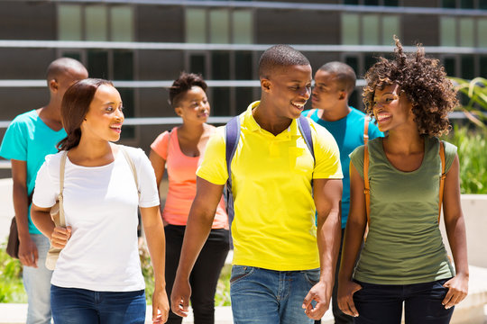

- Student Information
- Student ID
- Demographic Details
- Study Habits
- Parental Involvement
- Extracurricular Activities
- Academic Performance
- Target Variable: Grade Class

## Student Information

### Student ID

- **StudentID:** A unique identifier assigned to each student (1001 to 3392).

## Demographic Details

- **Age:** The age of the students ranges from 15 to 18 years.
- **Gender:** Gender of the students, where 0 represents Male and 1 represents Female.
- **Ethnicity:** The ethnicity of the students, coded as follows:
  - 0: Caucasian
  - 1: African American
  - 2: Asian
  - 3: Other
- **ParentalEducation:** The education level of the parents, coded as follows:
  - 0: None
  - 1: High School
  - 2: Some College
  - 3: Bachelor's
  - 4: Higher

## Study Habits

- **StudyTimeWeekly:** Weekly study time in hours, ranging from 0 to 20.
- **Absences:** Number of absences during the school year, ranging from 0 to 30.
- **Tutoring:** Tutoring status, where 0 indicates No and 1 indicates Yes.

## Parental Involvement

- **ParentalSupport:** The level of parental support, coded as follows:
  - 0: None
  - 1: Low
  - 2: Moderate
  - 3: High
  - 4: Very High

## Extracurricular Activities

- **Extracurricular:** Participation in extracurricular activities, where 0 indicates No and 1 indicates Yes.
- **Sports:** Participation in sports, where 0 indicates No and 1 indicates Yes.
- **Music:** Participation in music activities, where 0 indicates No and 1 indicates Yes.
- **Volunteering:** Participation in volunteering, where 0 indicates No and 1 indicates Yes.

## Target Variable: Grade Class

- **GradeClass:** Classification of students' grades based on GPA:
  - 0: 'A' (GPA >= 3.5)
  - 1: 'B' (3.0 <= GPA < 3.5)
  - 2: 'C' (2.5 <= GPA < 3.0)
  - 3: 'D' (2.0 <= GPA < 2.5)
  - 4: 'F' (GPA < 2.0)

## Installing Libraries

```python
pip install lightgbm
```

```python
import pandas as pd
import numpy as np
import matplotlib.pyplot as plt
import seaborn as sns
from scipy import stats
%matplotlib inline

import warnings
warnings.filterwarnings("ignore")

from sklearn.model_selection import train_test_split
from sklearn.preprocessing import StandardScaler
from sklearn.model_selection import GridSearchCV
from sklearn.metrics import accuracy_score, classification_report, confusion_matrix, f1_score

from sklearn.tree import DecisionTreeClassifier
from sklearn.ensemble import RandomForestClassifier, GradientBoostingClassifier, AdaBoostClassifier
from sklearn.neighbors import KNeighborsClassifier
from sklearn.linear_model import LogisticRegression, SGDClassifier
from sklearn.svm import SVC
from xgboost import XGBClassifier
from lightgbm import LGBMClassifier

sns.set_theme(context='notebook', palette='pastel', style='whitegrid')
```

```python
df = pd.read_csv('/Users/JumpMan/Downloads/Kaggle DataSets /Student Performance Dataset/Student_performance_data _.csv')
df.head(20)
```

|  | StudentID | Age | Gender | Ethnicity | ParentalEducation | StudyTimeWeekly(In Hours) | Absences | Tutoring | ParentalSupport | Extracurricular | Sports | Music | Volunteering | GPA | GradeClass |
| --- | --- | --- | --- | --- | --- | --- | --- | --- | --- | --- | --- | --- | --- | --- | --- |
| 0 | 1001 | 17 | 1 | 0 | 2 | 19.833723 | 7 | 1 | 2 | 0 | 0 | 1 | 0 | 2.929196 | 2 |
| 1 | 1002 | 18 | 0 | 0 | 1 | 15.408756 | 0 | 0 | 1 | 0 | 0 | 0 | 0 | 3.042915 | 1 |
| 2 | 1003 | 15 | 0 | 2 | 3 | 4.210570 | 26 | 0 | 2 | 0 | 0 | 0 | 0 | 0.112602 | 4 |
| 3 | 1004 | 17 | 1 | 0 | 3 | 10.028829 | 14 | 0 | 3 | 1 | 0 | 0 | 0 | 2.054218 | 3 |
| 4 | 1005 | 17 | 1 | 0 | 2 | 4.672495 | 17 | 1 | 3 | 0 | 0 | 0 | 0 | 1.288061 | 4 |
| 5 | 1006 | 18 | 0 | 0 | 1 | 8.191219 | 0 | 0 | 1 | 1 | 0 | 0 | 0 | 3.084184 | 1 |
| 6 | 1007 | 15 | 0 | 1 | 1 | 15.601680 | 10 | 0 | 3 | 0 | 1 | 0 | 0 | 2.748237 | 2 |
| 7 | 1008 | 15 | 1 | 1 | 4 | 15.424496 | 22 | 1 | 1 | 1 | 0 | 0 | 0 | 1.360143 | 4 |
| 8 | 1009 | 17 | 0 | 0 | 0 | 4.562008 | 1 | 0 | 2 | 0 | 1 | 0 | 1 | 2.896819 | 2 |
| 9 | 1010 | 16 | 1 | 0 | 1 | 18.444466 | 0 | 0 | 3 | 1 | 0 | 0 | 0 | 3.573474 | 0 |
| 10 | 1011 | 17 | 0 | 0 | 1 | 11.851364 | 11 | 0 | 1 | 0 | 0 | 0 | 0 | 2.147172 | 3 |
| 11 | 1012 | 17 | 0 | 0 | 1 | 7.598486 | 15 | 0 | 2 | 0 | 0 | 0 | 1 | 1.559595 | 4 |
| 12 | 1013 | 17 | 0 | 1 | 1 | 10.038712 | 21 | 0 | 3 | 1 | 0 | 0 | 0 | 1.520078 | 4 |
| 13 | 1014 | 17 | 0 | 1 | 2 | 12.101425 | 21 | 0 | 4 | 0 | 1 | 0 | 0 | 1.751581 | 4 |
| 14 | 1015 | 18 | 1 | 0 | 1 | 11.197811 | 9 | 1 | 2 | 0 | 0 | 0 | 0 | 2.396788 | 3 |
| 15 | 1016 | 15 | 0 | 0 | 2 | 9.728101 | 17 | 1 | 0 | 0 | 1 | 0 | 0 | 1.341521 | 4 |
| 16 | 1017 | 18 | 0 | 3 | 1 | 10.098656 | 14 | 0 | 2 | 1 | 1 | 0 | 0 | 2.232175 | 3 |
| 17 | 1018 | 18 | 1 | 0 | 0 | 3.528238 | 16 | 1 | 2 | 0 | 0 | 0 | 0 | 1.384404 | 4 |
| 18 | 1019 | 18 | 0 | 1 | 3 | 16.254658 | 29 | 0 | 2 | 1 | 0 | 0 | 1 | 0.469553 | 4 |
| 19 | 1020 | 17 | 0 | 0 | 1 | 10.835206 | 9 | 0 | 2 | 0 | 0 | 1 | 0 | 2.395784 | 3 |

```python
# Check for missing values
missing_values = df.isnull().sum()

# Display the missing values
print(missing_values)
#The Data is very clean
```

```
StudentID                    0
Age                          0
Gender                       0
Ethnicity                    0
ParentalEducation            0
StudyTimeWeekly(In Hours)    0
Absences                     0
Tutoring                     0
ParentalSupport              0
Extracurricular              0
Sports                       0
Music                        0
Volunteering                 0
GPA                          0
GradeClass                   0
dtype: int64
```

## Exploratory Analysis

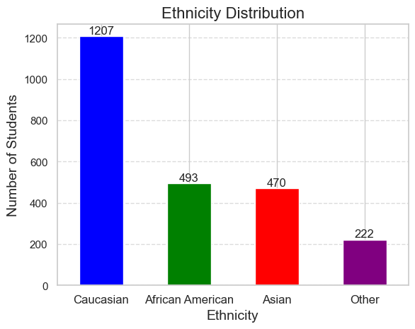

```python
# Calculate ethnicity distribution
ethnicity_distribution = df['Ethnicity'].value_counts()

# Plot the ethnicity distribution
fig, ax = plt.subplots()
bars = ethnicity_distribution.plot(kind='bar', color=['blue', 'green', 'red', 'purple'], ax=ax)

# Add labels on top of the bars
for bar in bars.patches:
    ax.annotate(f'{bar.get_height()}',
                (bar.get_x() + bar.get_width() / 2, bar.get_height()),
                ha='center', va='bottom', fontsize=12)

# Customize the plot
ax.set_xlabel('Ethnicity', fontsize=14)
ax.set_ylabel('Number of Students', fontsize=14)
ax.set_title('Ethnicity Distribution', fontsize=16)
ax.set_xticks([0, 1, 2, 3])
ax.set_xticklabels(['Caucasian', 'African American', 'Asian', 'Other'], rotation=0, fontsize=12)
ax.grid(axis='y', linestyle='--', alpha=0.7)

# Show the plot
plt.show()
```

[figure not shown]

```python
# Calculate GradeClass distribution
grade_class_distribution = df['GradeClass'].value_counts()

# Plot the GradeClass distribution
fig, ax = plt.subplots()
bars = grade_class_distribution.plot(kind='bar', color=['blue', 'green', 'yellow', 'orange', 'red'], ax=ax)

# Add labels on top of the bars
for bar in bars.patches:
    ax.annotate(f'{bar.get_height()}',
                (bar.get_x() + bar.get_width() / 2, bar.get_height()),
                ha='center', va='bottom', fontsize=12)

# Customize the plot
ax.set_xlabel('Grade Class', fontsize=14)
ax.set_ylabel('Number of Students', fontsize=14)
ax.set_title('Grade Class Distribution', fontsize=16)
ax.set_xticks(range(len(grade_class_distribution)))
ax.set_xticklabels(['A', 'B', 'C', 'D', 'F'], rotation=0, fontsize=12)
ax.grid(axis='y', linestyle='--', alpha=0.7)

# Show the plot
plt.show()
```

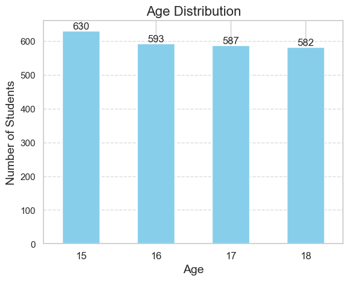

```python
import pandas as pd
import matplotlib.pyplot as plt

# Load the dataset
df = pd.read_csv('/Users/JumpMan/Downloads/Kaggle DataSets /Student Performance Dataset/Student_performance_data _.csv')

# Calculate Age distribution
age_distribution = df['Age'].value_counts().sort_index()

# Plot the Age distribution
fig, ax = plt.subplots()
bars = age_distribution.plot(kind='bar', color='skyblue', ax=ax)

# Add labels on top of the bars
for bar in bars.patches:
    ax.annotate(f'{bar.get_height()}',
                (bar.get_x() + bar.get_width() / 2, bar.get_height()),
                ha='center', va='bottom', fontsize=12)

# Customize the plot
ax.set_xlabel('Age', fontsize=14)
ax.set_ylabel('Number of Students', fontsize=14)
ax.set_title('Age Distribution', fontsize=16)
ax.set_xticks(range(len(age_distribution)))
ax.set_xticklabels(age_distribution.index, rotation=0, fontsize=12)
ax.grid(axis='y', linestyle='--', alpha=0.7)

# Show the plot
plt.show()
```

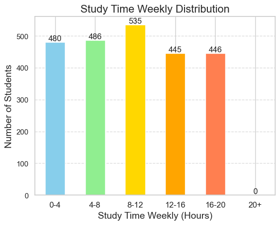

```python
import pandas as pd
import matplotlib.pyplot as plt

# Load the dataset
df = pd.read_csv('/Users/JumpMan/Downloads/Kaggle DataSets /Student Performance Dataset/Student_performance_data _.csv')

# Define the bins and labels
bins = [0, 4, 8, 12, 16, 20, float('inf')]
labels = ['0-4', '4-8', '8-12', '12-16', '16-20', '20+']

# Create a new column for the binned study time
df['StudyTimeWeeklyBins'] = pd.cut(df['StudyTimeWeekly(In Hours)'], bins=bins, labels=labels, right=False)

# Calculate the distribution
study_time_distribution = df['StudyTimeWeeklyBins'].value_counts().sort_index()

# Define colors for each bin
colors = ['skyblue', 'lightgreen', 'gold', 'orange', 'coral', 'purple']

# Plot the study time distribution
fig, ax = plt.subplots()
bars = study_time_distribution.plot(kind='bar', color=colors, ax=ax)

# Add labels on top of the bars
for bar in bars.patches:
    ax.annotate(f'{bar.get_height()}',
                (bar.get_x() + bar.get_width() / 2, bar.get_height()),
                ha='center', va='bottom', fontsize=12)

# Customize the plot
ax.set_xlabel('Study Time Weekly (Hours)', fontsize=14)
ax.set_ylabel('Number of Students', fontsize=14)
ax.set_title('Study Time Weekly Distribution', fontsize=16)
ax.set_xticks(range(len(study_time_distribution)))
ax.set_xticklabels(study_time_distribution.index, rotation=0, fontsize=12)
ax.grid(axis='y', linestyle='--', alpha=0.7)

# Show the plot
plt.show()
```

## African American analytical distribution

```python
pip install tabulate
```

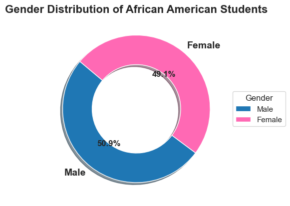

```python
# Filter the dataset for African American students
african_american_students = df[df['Ethnicity'] == 1]  # Assuming 1 represents African American

# Calculate gender distribution for African American students
gender_distribution_african_american = african_american_students['Gender'].value_counts()

# Define labels and colors
labels = ['Male', 'Female']
colors = ['#1f77b4', '#ff69b4']  # Use hex colors for better visual appeal

# Plot the gender distribution as a pie chart
fig, ax = plt.subplots()
wedges, texts, autotexts = ax.pie(gender_distribution_african_american,
                                  labels=labels,
                                  colors=colors,
                                  autopct='%1.1f%%',
                                  startangle=140,
                                  wedgeprops=dict(width=0.4, edgecolor='w'),
                                  shadow=True)

# Customize the plot
ax.set_title('Gender Distribution of African American Students', fontsize=16, fontweight='bold')

# Customize the text labels
for text in texts:
    text.set_fontsize(14)
    text.set_fontweight('bold')

for autotext in autotexts:
    autotext.set_fontsize(12)
    autotext.set_fontweight('bold')

# Add a legend
ax.legend(wedges, labels, title="Gender", loc="center left", bbox_to_anchor=(1, 0, 0.5, 1))

# Show the plot
plt.show()
```

```python
df.head()
```

|  | StudentID | Age | Gender | Ethnicity | ParentalEducation | StudyTimeWeekly(In Hours) | Absences | Tutoring | ParentalSupport | Extracurricular | Sports | Music | Volunteering | GPA | GradeClass | StudyTimeWeeklyBins |
| --- | --- | --- | --- | --- | --- | --- | --- | --- | --- | --- | --- | --- | --- | --- | --- | --- |
| 0 | 1001 | 17 | 1 | 0 | 2 | 19.833723 | 7 | 1 | 2 | 0 | 0 | 1 | 0 | 2.929196 | 2 | 16-20 |
| 1 | 1002 | 18 | 0 | 0 | 1 | 15.408756 | 0 | 0 | 1 | 0 | 0 | 0 | 0 | 3.042915 | 1 | 12-16 |
| 2 | 1003 | 15 | 0 | 2 | 3 | 4.210570 | 26 | 0 | 2 | 0 | 0 | 0 | 0 | 0.112602 | 4 | 4-8 |
| 3 | 1004 | 17 | 1 | 0 | 3 | 10.028829 | 14 | 0 | 3 | 1 | 0 | 0 | 0 | 2.054218 | 3 | 8-12 |
| 4 | 1005 | 17 | 1 | 0 | 2 | 4.672495 | 17 | 1 | 3 | 0 | 0 | 0 | 0 | 1.288061 | 4 | 4-8 |

**African American Gender Divide Statistics**

```python
from IPython.display import HTML
# Filter the dataset for African American students
african_american_students = df[df['Ethnicity'] == 1]  # Assuming 1 represents African American

# Further split by gender
african_american_boys = african_american_students[african_american_students['Gender'] == 0]  # Assuming 0 represents Male
african_american_girls = african_american_students[african_american_students['Gender'] == 1]  # Assuming 1 represents Female

# List of columns to analyze
columns = ['StudyTimeWeekly(In Hours)', 'Absences', 'Tutoring', 'ParentalEducation', 'ParentalSupport',
           'Extracurricular', 'Sports', 'Music', 'Volunteering', 'GPA', 'GradeClass']

# Define function to compute statistics
def compute_statistics(df_group, variable):
    mean = df_group[variable].mean()
    median = df_group[variable].median()
    mode = df_group[variable].mode().values[0]
    data_range = df_group[variable].max() - df_group[variable].min()
    return mean, median, mode, data_range

# Create lists to store results
results_boys = []
results_girls = []

# Calculate and store statistics for boys
for variable in columns:
    mean, median, mode, data_range = compute_statistics(african_american_boys, variable)
    results_boys.append([variable, mean, median, mode, data_range])

# Calculate and store statistics for girls
for variable in columns:
    mean, median, mode, data_range = compute_statistics(african_american_girls, variable)
    results_girls.append([variable, mean, median, mode, data_range])

# Create DataFrames for the results
results_boys_df = pd.DataFrame(results_boys, columns=['Variable', 'Mean', 'Median', 'Mode', 'Range'])
results_girls_df = pd.DataFrame(results_girls, columns=['Variable', 'Mean', 'Median', 'Mode', 'Range'])

# Prepare HTML for display with headings
boys_html = results_boys_df.to_html(classes='table table-striped', index=False)
girls_html = results_girls_df.to_html(classes='table table-striped', index=False)

combined_html = (
    "<h2>African American Boys Statistics</h2>" + boys_html +
    "<br><h2>African American Girls Statistics</h2>" + girls_html
)

# Display the results side by side using HTML for Jupyter Notebooks
display(HTML(combined_html))
```

African American Boys Statistics

| Variable | Mean | Median | Mode | Range |
| --- | --- | --- | --- | --- |
| StudyTimeWeekly(In Hours) | 9.854576 | 9.943346 | 0.16903 | 19.635421 |
| Absences | 13.764940 | 13.000000 | 6.00000 | 29.000000 |
| Tutoring | 0.306773 | 0.000000 | 0.00000 | 1.000000 |
| ParentalEducation | 1.701195 | 2.000000 | 2.00000 | 4.000000 |
| ParentalSupport | 2.111554 | 2.000000 | 2.00000 | 4.000000 |
| Extracurricular | 0.454183 | 0.000000 | 0.00000 | 1.000000 |
| Sports | 0.314741 | 0.000000 | 0.00000 | 1.000000 |
| Music | 0.191235 | 0.000000 | 0.00000 | 1.000000 |
| Volunteering | 0.159363 | 0.000000 | 0.00000 | 1.000000 |
| GPA | 1.999385 | 1.950769 | 0.00000 | 3.869587 |
| GradeClass | 2.940239 | 3.000000 | 4.00000 | 4.000000 |

African American Girls Statistics

| Variable | Mean | Median | Mode | Range |
| --- | --- | --- | --- | --- |
| StudyTimeWeekly(In Hours) | 10.007046 | 9.888401 | 0.004859 | 19.94360 |
| Absences | 14.566116 | 14.000000 | 27.000000 | 29.00000 |
| Tutoring | 0.268595 | 0.000000 | 0.000000 | 1.00000 |
| ParentalEducation | 1.743802 | 2.000000 | 2.000000 | 4.00000 |
| ParentalSupport | 1.987603 | 2.000000 | 2.000000 | 4.00000 |
| Extracurricular | 0.400826 | 0.000000 | 0.000000 | 1.00000 |
| Sports | 0.289256 | 0.000000 | 0.000000 | 1.00000 |
| Music | 0.177686 | 0.000000 | 0.000000 | 1.00000 |
| Volunteering | 0.128099 | 0.000000 | 0.000000 | 1.00000 |
| GPA | 1.891520 | 1.927973 | 0.000000 | 3.95146 |
| GradeClass | 2.942149 | 3.000000 | 4.000000 | 4.00000 |

```python
# Further split by gender
african_american_boys = african_american_students[african_american_students['Gender'] == 0]  # Assuming 0 represents Male
african_american_girls = african_american_students[african_american_students['Gender'] == 1]  # Assuming 1 represents Female

# Define GPA bins
gpa_bins = [2.0, 2.5, 3.0, 3.5, 4.0]
gpa_labels = ['2.0-2.5', '2.5-3.0', '3.0-3.5', '3.5-4.0']

# List of columns to analyze
columns = ['StudyTimeWeekly(In Hours)', 'Absences', 'Tutoring', 'ParentalSupport', 'ParentalEducation',
           'Extracurricular', 'Sports', 'Music', 'Volunteering', 'GradeClass']

# Define function to compute the mean
def compute_mean(df_group, variable):
    return df_group[variable].mean()

# Function to compute means for each GPA range and organize the data
def compute_gpa_range_means(df_group, gpa_bins, gpa_labels):
    df_group['GPA_Range'] = pd.cut(df_group['GPA'], bins=gpa_bins, labels=gpa_labels, right=False)
    means_data = {}

    for label in gpa_labels:
        gpa_range_group = df_group[df_group['GPA_Range'] == label]
        if not gpa_range_group.empty:
            means = {var: compute_mean(gpa_range_group, var) for var in columns}
            means_data[label] = means

    return means_data

# Calculate means for boys and girls in each GPA range
means_boys = compute_gpa_range_means(african_american_boys, gpa_bins, gpa_labels)
means_girls = compute_gpa_range_means(african_american_girls, gpa_bins, gpa_labels)

# Create DataFrames for the results
means_boys_df = pd.DataFrame(means_boys).T
means_boys_df.index.name = 'GPA Range'
means_boys_df.reset_index(inplace=True)

means_girls_df = pd.DataFrame(means_girls).T
means_girls_df.index.name = 'GPA Range'
means_girls_df.reset_index(inplace=True)

# Rename columns to include variable names
means_boys_df.columns = ['GPA Range'] + columns
means_girls_df.columns = ['GPA Range'] + columns

# Prepare HTML for display with headings
boys_html = means_boys_df.to_html(classes='table table-striped', index=False)
girls_html = means_girls_df.to_html(classes='table table-striped', index=False)

# Display the results for boys and girls separately in separate cells
display(HTML("<h2>African American Boys Mean Statistics by GPA Range</h2>" + boys_html))
display(HTML("<h2>African American Girls Mean Statistics by GPA Range</h2>" + girls_html))
```

African American Boys Mean Statistics by GPA Range

| GPA Range | StudyTimeWeekly(In Hours) | Absences | Tutoring | ParentalSupport | ParentalEducation | Extracurricular | Sports | Music | Volunteering | GradeClass |
| --- | --- | --- | --- | --- | --- | --- | --- | --- | --- | --- |
| 2.0-2.5 | 9.534017 | 10.375000 | 0.225000 | 2.200000 | 1.525000 | 0.425000 | 0.250000 | 0.175000 | 0.150000 | 2.900000 |
| 2.5-3.0 | 10.487434 | 6.489362 | 0.276596 | 2.148936 | 1.510638 | 0.595745 | 0.361702 | 0.170213 | 0.255319 | 2.000000 |
| 3.0-3.5 | 11.249041 | 3.629630 | 0.444444 | 2.296296 | 1.888889 | 0.407407 | 0.407407 | 0.222222 | 0.185185 | 1.074074 |
| 3.5-4.0 | 13.394114 | 2.555556 | 0.666667 | 2.111111 | 2.000000 | 0.555556 | 0.333333 | 0.333333 | 0.222222 | 0.000000 |

African American Girls Mean Statistics by GPA Range

| GPA Range | StudyTimeWeekly(In Hours) | Absences | Tutoring | ParentalSupport | ParentalEducation | Extracurricular | Sports | Music | Volunteering | GradeClass |
| --- | --- | --- | --- | --- | --- | --- | --- | --- | --- | --- |
| 2.0-2.5 | 10.871199 | 10.957447 | 0.234043 | 1.765957 | 1.787234 | 0.425532 | 0.191489 | 0.170213 | 0.127660 | 2.978723 |
| 2.5-3.0 | 9.935198 | 6.575758 | 0.363636 | 2.151515 | 1.666667 | 0.454545 | 0.272727 | 0.212121 | 0.181818 | 2.000000 |
| 3.0-3.5 | 9.267392 | 3.000000 | 0.576923 | 2.307692 | 2.000000 | 0.346154 | 0.423077 | 0.192308 | 0.153846 | 1.000000 |
| 3.5-4.0 | 11.666370 | 0.900000 | 0.300000 | 3.200000 | 1.500000 | 0.700000 | 0.200000 | 0.100000 | 0.000000 | 0.000000 |

```python
# Filter the dataset for African American students
african_american_students = df[df['Ethnicity'] == 1]  # Assuming 1 represents African American

# Further split by gender
african_american_boys = african_american_students[african_american_students['Gender'] == 0]  # Assuming 0 represents Male
african_american_girls = african_american_students[african_american_students['Gender'] == 1]  # Assuming 1 represents Female

# Define GPA bins
gpa_bins = [2.0, 2.5, 3.0, 3.5, 4.0]
gpa_labels = ['2.0-2.5', '2.5-3.0', '3.0-3.5', '3.5-4.0']

# Function to compute student count for each GPA range
def compute_gpa_range_counts(df_group, gpa_bins, gpa_labels):
    df_group['GPA_Range'] = pd.cut(df_group['GPA'], bins=gpa_bins, labels=gpa_labels, right=False)
    counts = df_group['GPA_Range'].value_counts(sort=False)  # Keep order of gpa_labels
    return counts

# Calculate student counts for boys and girls in each GPA range
counts_boys = compute_gpa_range_counts(african_american_boys, gpa_bins, gpa_labels)
counts_girls = compute_gpa_range_counts(african_american_girls, gpa_bins, gpa_labels)

# Create DataFrames for the results
counts_boys_df = counts_boys.reset_index()
counts_boys_df.columns = ['GPA Range', 'Number of Students']

counts_girls_df = counts_girls.reset_index()
counts_girls_df.columns = ['GPA Range', 'Number of Students']

# Prepare HTML for display with headings
boys_counts_html = counts_boys_df.to_html(classes='table table-striped', index=False)
girls_counts_html = counts_girls_df.to_html(classes='table table-striped', index=False)

# Display the results for boys and girls separately in separate cells
display(HTML("<h2>African American Boys Count of Students by GPA Range</h2>" + boys_counts_html))
display(HTML("<h2>African American Girls Count of Students by GPA Range</h2>" + girls_counts_html))
```

African American Boys Count of Students by GPA Range

| GPA Range | Number of Students |
| --- | --- |
| 2.0-2.5 | 40 |
| 2.5-3.0 | 47 |
| 3.0-3.5 | 27 |
| 3.5-4.0 | 9 |

African American Girls Count of Students by GPA Range

| GPA Range | Number of Students |
| --- | --- |
| 2.0-2.5 | 47 |
| 2.5-3.0 | 33 |
| 3.0-3.5 | 26 |
| 3.5-4.0 | 10 |

**Correlation Matrix for African American Boys and Girls**

```python
# Filter the dataset for African American students
african_american_students = df[df['Ethnicity'] == 1]  # Assuming 1 represents African American

# Further split by gender
african_american_boys = african_american_students[african_american_students['Gender'] == 0]  # Assuming 0 represents Male
african_american_girls = african_american_students[african_american_students['Gender'] == 1]  # Assuming 1 represents Female

# List of columns to analyze
columns = ['StudyTimeWeekly(In Hours)', 'Absences', 'Tutoring', 'ParentalSupport', 'ParentalEducation',
           'Extracurricular', 'Sports', 'Music', 'Volunteering', 'GPA', 'GradeClass']

# Create correlation matrices
corr_matrix_boys = african_american_boys[columns].corr()
corr_matrix_girls = african_american_girls[columns].corr()
# Extract and sort the correlations with GPA
gpa_corr_boys = corr_matrix_boys['GPA'].drop('GPA').sort_values(ascending=False)
gpa_corr_girls = corr_matrix_girls['GPA'].drop('GPA').sort_values(ascending=False)
```

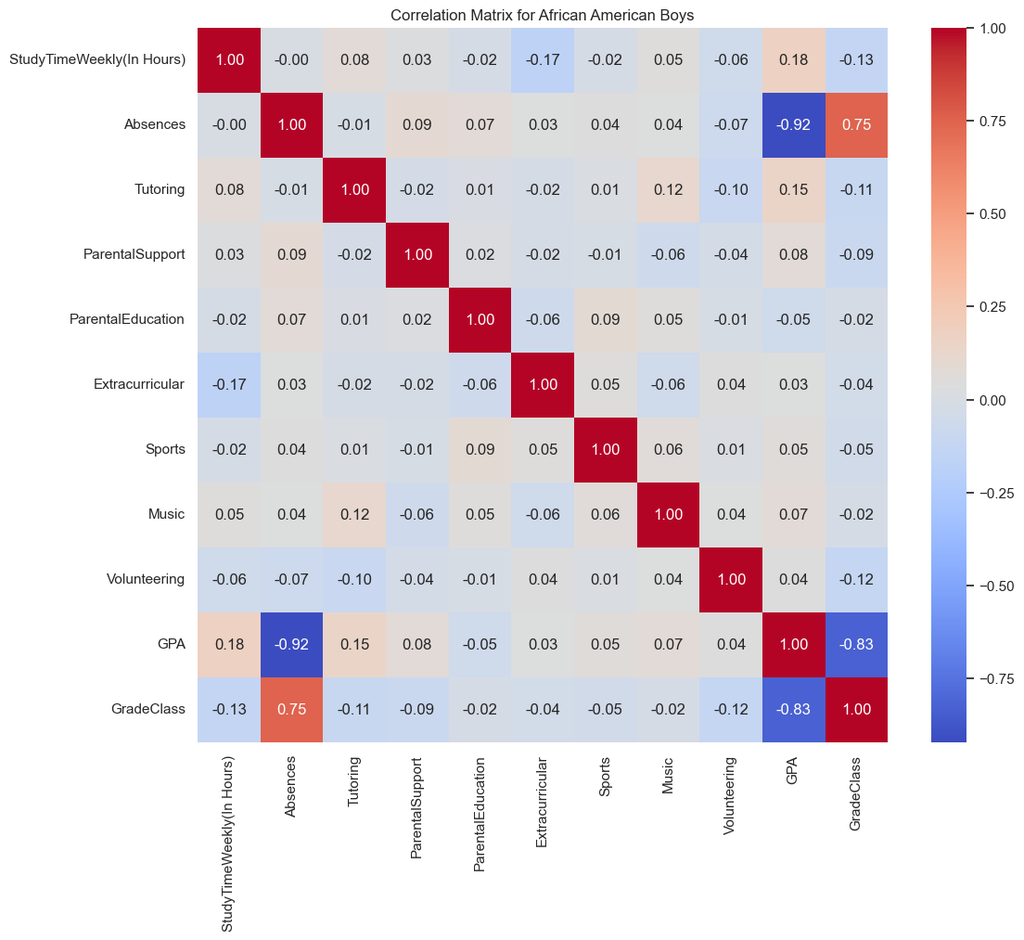

```
Top variables determining GPA for African American boys:
StudyTimeWeekly(In Hours)    0.178618
Tutoring                     0.148355
ParentalSupport              0.076099
Music                        0.073803
Sports                       0.054859
Volunteering                 0.042079
Extracurricular              0.032105
ParentalEducation           -0.052975
GradeClass                  -0.830687
Absences                    -0.921467
Name: GPA, dtype: float64
```

```python
# Plot correlation matrix for boys
plt.figure(figsize=(12, 10))
sns.heatmap(corr_matrix_boys, annot=True, cmap='coolwarm', fmt=".2f")
plt.title('Correlation Matrix for African American Boys')
plt.show()
# Print the top variables determining GPA
print("Top variables determining GPA for African American boys:")
print(gpa_corr_boys)
```

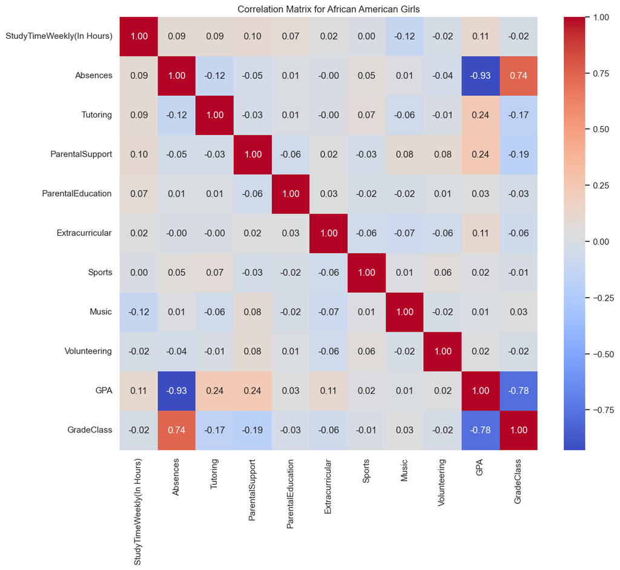

```
Top variables determining GPA for African American girls:
Tutoring                     0.243252
ParentalSupport              0.236631
StudyTimeWeekly(In Hours)    0.106689
Extracurricular              0.106537
ParentalEducation            0.033085
Volunteering                 0.021864
Sports                       0.019659
Music                        0.011206
GradeClass                  -0.776395
Absences                    -0.928764
Name: GPA, dtype: float64
```

```python
# Plot correlation matrix for girls
plt.figure(figsize=(12, 10))
sns.heatmap(corr_matrix_girls, annot=True, cmap='coolwarm', fmt=".2f")
plt.title('Correlation Matrix for African American Girls')
plt.show()

print("\nTop variables determining GPA for African American girls:")
print(gpa_corr_girls)
```

## Gender Distribution of All Students

```python
# List of columns to analyze
columns = ['StudyTimeWeekly(In Hours)', 'Absences', 'Tutoring', 'ParentalSupport', 'ParentalEducation',
           'Extracurricular', 'Sports', 'Music', 'Volunteering', 'GPA', 'GradeClass']

# Define function to compute statistics
def compute_statistics(df_group, variable):
    mean = df_group[variable].mean()
    median = df_group[variable].median()
    mode = df_group[variable].mode().values[0]
    data_range = df_group[variable].max() - df_group[variable].min()
    return mean, median, mode, data_range

# Create lists to store results
results_overall = []

# Calculate and store statistics for the overall population
for variable in columns:
    mean, median, mode, data_range = compute_statistics(df, variable)
    results_overall.append([variable, mean, median, mode, data_range])

# Create DataFrame for the results
results_overall_df = pd.DataFrame(results_overall, columns=['Variable', 'Mean', 'Median', 'Mode', 'Range'])

# Prepare HTML for display with headings
overall_html = results_overall_df.to_html(classes='table table-striped', index=False)

# Display the results for the overall population
display(HTML("<h2>Overall Population Statistics</h2>" + overall_html))
```

Overall Population Statistics

| Variable | Mean | Median | Mode | Range |
| --- | --- | --- | --- | --- |
| StudyTimeWeekly(In Hours) | 9.771992 | 9.705363 | 0.001057 | 19.977037 |
| Absences | 14.541388 | 15.000000 | 13.000000 | 29.000000 |
| Tutoring | 0.301421 | 0.000000 | 0.000000 | 1.000000 |
| ParentalSupport | 2.122074 | 2.000000 | 2.000000 | 4.000000 |
| ParentalEducation | 1.746237 | 2.000000 | 2.000000 | 4.000000 |
| Extracurricular | 0.383361 | 0.000000 | 0.000000 | 1.000000 |
| Sports | 0.303512 | 0.000000 | 0.000000 | 1.000000 |
| Music | 0.196906 | 0.000000 | 0.000000 | 1.000000 |
| Volunteering | 0.157191 | 0.000000 | 0.000000 | 1.000000 |
| GPA | 1.906186 | 1.893393 | 0.000000 | 4.000000 |
| GradeClass | 2.983696 | 4.000000 | 4.000000 | 4.000000 |

```python
import pandas as pd
from IPython.display import display, HTML

# Load the dataset
df = pd.read_csv('/Users/JumpMan/Downloads/Kaggle DataSets /Student Performance Dataset/Student_performance_data _.csv')

# Further split by gender
all_boys = df[df['Gender'] == 0]  # Assuming 0 represents Male
all_girls = df[df['Gender'] == 1]  # Assuming 1 represents Female

# Define GPA bins
gpa_bins = [2.0, 2.5, 3.0, 3.5, 4.0]
gpa_labels = ['2.0-2.5', '2.5-3.0', '3.0-3.5', '3.5-4.0']

# List of columns to analyze
columns = ['StudyTimeWeekly(In Hours)', 'Absences', 'Tutoring', 'ParentalSupport', 'ParentalEducation',
           'Extracurricular', 'Sports', 'Music', 'Volunteering', 'GradeClass']

# Define function to compute the mean
def compute_mean(df_group, variable):
    return df_group[variable].mean()

# Function to compute means for each GPA range and organize the data
def compute_gpa_range_means(df_group, gpa_bins, gpa_labels):
    df_group['GPA_Range'] = pd.cut(df_group['GPA'], bins=gpa_bins, labels=gpa_labels, right=False)
    means_data = {}

    for label in gpa_labels:
        gpa_range_group = df_group[df_group['GPA_Range'] == label]
        if not gpa_range_group.empty:
            means = {var: compute_mean(gpa_range_group, var) for var in columns}
            means_data[label] = means

    return means_data

# Calculate means for boys and girls in each GPA range
means_boys = compute_gpa_range_means(all_boys, gpa_bins, gpa_labels)
means_girls = compute_gpa_range_means(all_girls, gpa_bins, gpa_labels)

# Create DataFrames for the results
means_boys_df = pd.DataFrame(means_boys).T
means_boys_df.index.name = 'GPA Range'
means_boys_df.reset_index(inplace=True)

means_girls_df = pd.DataFrame(means_girls).T
means_girls_df.index.name = 'GPA Range'
means_girls_df.reset_index(inplace=True)

# Rename columns to include variable names
means_boys_df.columns = ['GPA Range'] + columns
means_girls_df.columns = ['GPA Range'] + columns

# Prepare HTML for display with headings
boys_html = means_boys_df.to_html(classes='table table-striped', index=False)
girls_html = means_girls_df.to_html(classes='table table-striped', index=False)

# Display the results for boys and girls separately in separate cells
display(HTML("<h2>All Boys Mean Statistics by GPA Range</h2>" + boys_html))
display(HTML("<h2>All Girls Mean Statistics by GPA Range</h2>" + girls_html))
```

All Boys Mean Statistics by GPA Range

| GPA Range | StudyTimeWeekly(In Hours) | Absences | Tutoring | ParentalSupport | ParentalEducation | Extracurricular | Sports | Music | Volunteering | GradeClass |
| --- | --- | --- | --- | --- | --- | --- | --- | --- | --- | --- |
| 2.0-2.5 | 9.589024 | 10.812808 | 0.285714 | 2.108374 | 1.694581 | 0.349754 | 0.359606 | 0.187192 | 0.128079 | 2.896552 |
| 2.5-3.0 | 9.710143 | 6.364583 | 0.307292 | 2.171875 | 1.677083 | 0.406250 | 0.255208 | 0.192708 | 0.187500 | 1.989583 |
| 3.0-3.5 | 11.321741 | 3.451613 | 0.459677 | 2.459677 | 1.798387 | 0.459677 | 0.387097 | 0.225806 | 0.177419 | 1.153226 |
| 3.5-4.0 | 13.398997 | 1.848485 | 0.666667 | 2.636364 | 1.606061 | 0.454545 | 0.393939 | 0.363636 | 0.121212 | 0.121212 |

All Girls Mean Statistics by GPA Range

| GPA Range | StudyTimeWeekly(In Hours) | Absences | Tutoring | ParentalSupport | ParentalEducation | Extracurricular | Sports | Music | Volunteering | GradeClass |
| --- | --- | --- | --- | --- | --- | --- | --- | --- | --- | --- |
| 2.0-2.5 | 10.201644 | 11.440191 | 0.277512 | 2.167464 | 1.808612 | 0.377990 | 0.277512 | 0.181818 | 0.177033 | 2.918660 |
| 2.5-3.0 | 10.491647 | 6.694301 | 0.279793 | 2.129534 | 1.647668 | 0.419689 | 0.274611 | 0.196891 | 0.103627 | 1.979275 |
| 3.0-3.5 | 11.394749 | 3.233333 | 0.375000 | 2.400000 | 1.741667 | 0.400000 | 0.325000 | 0.283333 | 0.158333 | 1.075000 |
| 3.5-4.0 | 11.865399 | 1.540541 | 0.486486 | 2.918919 | 1.675676 | 0.702703 | 0.459459 | 0.189189 | 0.108108 | 0.162162 |

**Number of Students for each GPA Level**

```python
# Further split by gender
all_boys = df[df['Gender'] == 0]  # Assuming 0 represents Male
all_girls = df[df['Gender'] == 1]  # Assuming 1 represents Female

# Define GPA bins
gpa_bins = [2.0, 2.5, 3.0, 3.5, 4.0]
gpa_labels = ['2.0-2.5', '2.5-3.0', '3.0-3.5', '3.5-4.0']

# Function to compute student count for each GPA range
def compute_gpa_range_counts(df_group, gpa_bins, gpa_labels):
    df_group['GPA_Range'] = pd.cut(df_group['GPA'], bins=gpa_bins, labels=gpa_labels, right=False)
    counts = df_group['GPA_Range'].value_counts(sort=False)  # Keep order of gpa_labels
    return counts

# Calculate student counts for boys and girls in each GPA range
counts_boys = compute_gpa_range_counts(all_boys, gpa_bins, gpa_labels)
counts_girls = compute_gpa_range_counts(all_girls, gpa_bins, gpa_labels)

# Create DataFrames for the results
counts_boys_df = counts_boys.reset_index()
counts_boys_df.columns = ['GPA Range', 'Number of Students']

counts_girls_df = counts_girls.reset_index()
counts_girls_df.columns = ['GPA Range', 'Number of Students']

# Display the results for boys and girls separately
print("All Boys Count of Students by GPA Range")
print(counts_boys_df)

print("\nAll Girls Count of Students by GPA Range")
print(counts_girls_df)
```

```
All Boys Count of Students by GPA Range
  GPA Range  Number of Students
0   2.0-2.5                 203
1   2.5-3.0                 192
2   3.0-3.5                 124
3   3.5-4.0                  33

All Girls Count of Students by GPA Range
  GPA Range  Number of Students
0   2.0-2.5                 209
1   2.5-3.0                 193
2   3.0-3.5                 120
3   3.5-4.0                  37
```

# Machine Learning Analysis

## Decision Tree Classifier

```
Accuracy: 0.83

Classification Report:
              precision    recall  f1-score   support

           0       0.65      0.59      0.62        22
           1       0.64      0.84      0.73        49
           2       0.87      0.78      0.82        85
           3       0.82      0.79      0.80        86
           4       0.89      0.89      0.89       237

    accuracy                           0.83       479
   macro avg       0.77      0.78      0.77       479
weighted avg       0.84      0.83      0.83       479


Confusion Matrix:
[[ 13   2   2   2   3]
 [  0  41   1   3   4]
 [  4   4  66   4   7]
 [  1   4   2  68  11]
 [  2  13   5   6 211]]

Feature Importance:
                      feature  importance
12                        GPA    0.858372
4   StudyTimeWeekly(In Hours)    0.051031
5                    Absences    0.020249
2                   Ethnicity    0.014006
7             ParentalSupport    0.011224
3           ParentalEducation    0.010662
0                         Age    0.010504
9                      Sports    0.006221
11               Volunteering    0.005594
6                    Tutoring    0.003749
1                      Gender    0.003102
10                      Music    0.002746
8             Extracurricular    0.002540
```

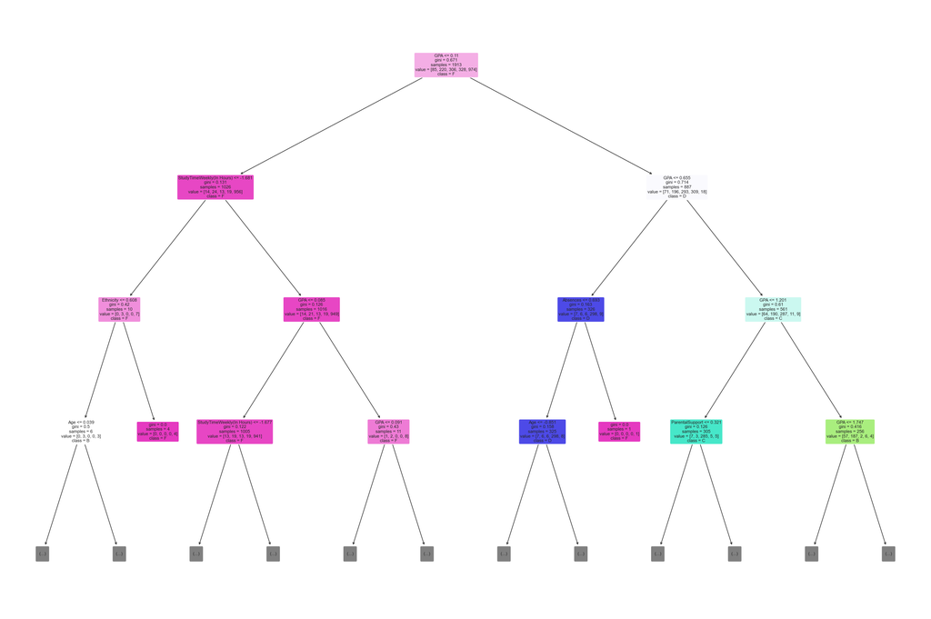

```python
# Import necessary libraries
from sklearn.tree import DecisionTreeClassifier
from sklearn.model_selection import train_test_split
from sklearn.preprocessing import StandardScaler
from sklearn.metrics import accuracy_score, classification_report, confusion_matrix
import pandas as pd
import matplotlib.pyplot as plt
from sklearn.tree import plot_tree

# Prepare the features and target variable
X = df[['Age', 'Gender', 'Ethnicity', 'ParentalEducation', 'StudyTimeWeekly(In Hours)',
        'Absences', 'Tutoring', 'ParentalSupport', 'Extracurricular', 'Sports',
        'Music', 'Volunteering', 'GPA']]
y = df['GradeClass']

# Split the data into training and testing sets
X_train, X_test, y_train, y_test = train_test_split(X, y, test_size=0.2, random_state=42)

# Scale the features
scaler = StandardScaler()
X_train_scaled = scaler.fit_transform(X_train)
X_test_scaled = scaler.transform(X_test)

# Initialize and train the Decision Tree Classifier
dt_classifier = DecisionTreeClassifier(random_state=42)
dt_classifier.fit(X_train_scaled, y_train)

# Make predictions
y_pred = dt_classifier.predict(X_test_scaled)

# Evaluate the model
accuracy = accuracy_score(y_test, y_pred)
print(f"Accuracy: {accuracy:.2f}")

print("\nClassification Report:")
print(classification_report(y_test, y_pred))

print("\nConfusion Matrix:")
print(confusion_matrix(y_test, y_pred))

# Feature importance
feature_importance = dt_classifier.feature_importances_
feature_names = X.columns
importance_df = pd.DataFrame({'feature': feature_names, 'importance': feature_importance})
importance_df = importance_df.sort_values('importance', ascending=False)

print("\nFeature Importance:")
print(importance_df)

# Visualize the decision tree (limited to depth 3 for clarity)
# Define class names
class_names = ['A', 'B', 'C', 'D', 'F']

# Visualize the decision tree (limited to depth 3 for clarity)
plt.figure(figsize=(30,20))
plot_tree(dt_classifier,
          max_depth=3,
          feature_names=list(X.columns),
          class_names=class_names,  # Use the defined class names
          filled=True,
          rounded=True)
plt.show()
```

### Model Performance Analysis of Decision Tree Classifier for Predicting Student Grade Classes

#### Model Accuracy

- The overall accuracy of the model is **0.83**, indicating that it correctly predicts the grade class for **83%** of the students in the test set. This demonstrates a good overall performance.

#### Classification Report

- The model performs well across all grade classes (0-4), with F1-scores ranging from **0.62 to 0.89**.
- It is particularly effective at predicting class 4 (likely representing F grades), with precision, recall, and F1-score all at **0.89**.
- The model has some difficulty with class 0 (likely representing A grades), showing lower precision (**0.65**) and recall (**0.59**).

#### Confusion Matrix

- The diagonal elements show correct predictions, which are generally high.
- There is some misclassification between adjacent classes, which is expected given the ordinal nature of grades.
- The model performs particularly well for class 4, with **211 correct predictions out of 237 instances**.

#### Feature Importance

- **GPA** is by far the most important feature, with an importance score of **0.858372**.
- **StudyTimeWeekly** and **Absences** are the next most important features, but with much lower scores.
- **Ethnicity** ranks 4th in importance, suggesting it does have some impact on grade prediction, but not as much as academic performance metrics.
- **Gender** and **extracurricular activities** have relatively low importance in the model's predictions.

#### Summary

- The Decision Tree Classifier shows good overall performance in predicting student grade classes, with particular strength in identifying lower-performing students.
- GPA is the dominant predictor, which is logical given its direct relationship to grades. Study time and attendance also play significant roles.
- Demographic factors like ethnicity and gender have some influence but are not primary determinants in the model's predictions.
- The model's performance varies across grade classes, being most accurate for lower grades and less so for top grades. This suggests that high-achieving students might have more diverse or complex factors influencing their performance that the model doesn't fully capture.

#### Implications for Educators

- These results indicate that academic behaviors and performance metrics are the most reliable predictors of grade outcomes, while demographic factors play a secondary role.
- This information could be valuable for educators in identifying at-risk students and understanding the key factors influencing academic success.

## XGBoost for predicting GPA

```python
from xgboost import XGBRegressor
from sklearn.model_selection import train_test_split
from sklearn.metrics import mean_squared_error, r2_score
from sklearn.preprocessing import LabelEncoder

# Prepare the data
X = df.drop(['StudentID', 'GPA', 'GradeClass'], axis=1)
y = df['GPA']

# Encode categorical variables
le = LabelEncoder()
for column in X.select_dtypes(include=['object']).columns:
    X[column] = le.fit_transform(X[column])

# Split the data
X_train, X_test, y_train, y_test = train_test_split(X, y, test_size=0.2, random_state=42)

# Initialize and train the XGBoost model
xgb_model = XGBRegressor(random_state=42)
xgb_model.fit(X_train, y_train)

# Make predictions
y_pred = xgb_model.predict(X_test)

# Evaluate the model
mse = mean_squared_error(y_test, y_pred)
r2 = r2_score(y_test, y_pred)

print(f"Mean Squared Error: {mse}")
print(f"R-squared Score: {r2}")

# Feature importance
feature_importance = xgb_model.feature_importances_
feature_importance_df = pd.DataFrame({'feature': X.columns, 'importance': feature_importance})
feature_importance_df = feature_importance_df.sort_values('importance', ascending=False)
print("\nFeature Importance:")
print(feature_importance_df)
```

```
Mean Squared Error: 0.057511884077026
R-squared Score: 0.9304515469597147

Feature Importance:
                      feature  importance
5                    Absences    0.716364
6                    Tutoring    0.064585
7             ParentalSupport    0.051056
8             Extracurricular    0.048582
9                      Sports    0.041480
10                      Music    0.026351
4   StudyTimeWeekly(In Hours)    0.023888
11               Volunteering    0.007082
3           ParentalEducation    0.005793
2                   Ethnicity    0.005288
1                      Gender    0.005009
0                         Age    0.004524
```

### Model Performance Analysis of XGBoost for Predicting Student GPA

#### Model Performance

- **Mean Squared Error (MSE)**: 0.057511884077026
  - This low MSE indicates that the model's predictions are close to the actual GPA values.
  - On average, the model's predictions deviate from the true GPA by about √0.057511 ≈ 0.24 GPA points.
- **R-squared Score**: 0.9304515469597147
  - This high R-squared value (93.05%) suggests that the model explains a large proportion of the variance in GPA.
  - The model accounts for about 93% of the variability in student GPAs, which is excellent.

#### Feature Importance

- **Absences (71.64%)**: By far the most crucial factor in predicting GPA. More absences strongly correlate with lower GPAs.
- **Tutoring (6.46%)**: The second most important feature, suggesting that receiving tutoring has a positive impact on GPA.
- **ParentalSupport (5.11%)**: The third most significant factor, indicating that parental involvement plays a role in academic performance.
- **Extracurricular (4.86%) and Sports (4.15%)**: These activities have a moderate influence on GPA prediction.
- **Music (2.64%) and StudyTimeWeekly (2.39%)**: These factors have a smaller but still notable impact on GPA.
- **Other factors (Volunteering, ParentalEducation, Ethnicity, Gender, Age)**: These have relatively minor influences on GPA prediction in this model.

#### Summary

The XGBoost model demonstrates high accuracy in predicting student GPAs, with a strong R-squared score and low mean squared error. The model's performance suggests it can be a reliable tool for estimating student academic performance.

##### Key Findings

- **Attendance is crucial**: The number of absences is overwhelmingly the most important factor in predicting GPA. This underscores the importance of regular school attendance for academic success.
- **Academic support matters**: Tutoring and parental support are the next most significant factors, highlighting the value of additional academic assistance and family involvement in education.
- **Extracurricular activities have an impact**: Participation in extracurricular activities, sports, and music all contribute to GPA prediction, suggesting a positive relationship between these activities and academic performance.
- **Demographic factors are less influential**: Ethnicity, gender, and age play relatively minor roles in GPA prediction in this model. This suggests that academic behaviors and support systems are more predictive of GPA than demographic characteristics.
- **Study time is less important than expected**: Weekly study time has a surprisingly low importance in the model, which could indicate that the quality of study time might be more important than the quantity.

#### Recommendations

- Focus on improving attendance rates as a primary strategy for boosting academic performance.
- Encourage and facilitate tutoring programs and parental involvement in students' education.
- Promote participation in extracurricular activities, sports, and music programs as they appear to positively influence academic performance.
- Investigate why study time appears less important and consider ways to improve the effectiveness of study habits.
- Use this model as a tool for early identification of students who may be at risk of lower GPAs, focusing on factors like attendance and access to academic support.

This model provides valuable insights into the factors influencing student GPAs and can be a useful tool for educators and administrators in developing targeted strategies to improve academic outcomes.

## User Input GPA and Grade Prediction

```python
from sklearn.tree import DecisionTreeClassifier
from sklearn.ensemble import RandomForestClassifier, GradientBoostingClassifier, AdaBoostClassifier
from sklearn.neighbors import KNeighborsClassifier
from sklearn.linear_model import LogisticRegression, SGDClassifier
from sklearn.svm import SVC
from xgboost import XGBClassifier
from lightgbm import LGBMClassifier
```

```python
import pandas as pd
from sklearn.preprocessing import LabelEncoder

# Assuming xgb_model and dt_classifier are already defined and trained

# Initialize LabelEncoder
le = LabelEncoder()

def get_user_input():
    print("Enter the following details to predict GPA and Grade Class:")

    while True:
        try:
            age = int(input("Age (15-18): "))
            if 15 <= age <= 18:
                break
            else:
                print("Invalid input. Please enter an age between 15 and 18.")
        except ValueError:
            print("Invalid input. Please enter an integer.")

    while True:
        try:
            gender = int(input("Gender (0 for Male, 1 for Female): "))
            if gender in [0, 1]:
                break
            else:
                print("Invalid input. Please enter 0 for Male or 1 for Female.")
        except ValueError:
            print("Invalid input. Please enter an integer.")

    while True:
        try:
            ethnicity = int(input("Ethnicity (0: Caucasian, 1: African American, 2: Asian, 3: Other): "))
            if ethnicity in [0, 1, 2, 3]:
                break
            else:
                print("Invalid input. Please enter 0, 1, 2, or 3.")
        except ValueError:
            print("Invalid input. Please enter an integer.")

    while True:
        try:
            parental_education = int(input("Parental Education (0: None, 1: High School, 2: Some College, 3: Bachelor's, 4: Higher): "))
            if parental_education in [0, 1, 2, 3, 4]:
                break
            else:
                print("Invalid input. Please enter 0, 1, 2, 3, or 4.")
        except ValueError:
            print("Invalid input. Please enter an integer.")

    while True:
        try:
            study_time = float(input("Weekly Study Time (0-20 hours): "))
            if 0 <= study_time <= 30:
                break
            else:
                print("Invalid input. Please enter a number between 0 and 20.")
        except ValueError:
            print("Invalid input. Please enter a number.")

    while True:
        try:
            absences = int(input("Number of Absences (0-30): "))
            if 0 <= absences <= 180:
                break
            else:
                print("Invalid input. Please enter a number between 0 and 30.")
        except ValueError:
            print("Invalid input. Please enter an integer.")

    while True:
        try:
            tutoring = int(input("Tutoring (0 for No, 1 for Yes): "))
            if tutoring in [0, 1]:
                break
            else:
                print("Invalid input. Please enter 0 for No or 1 for Yes.")
        except ValueError:
            print("Invalid input. Please enter an integer.")

    while True:
        try:
            parental_support = int(input("Parental Support (0: None, 1: Low, 2: Moderate, 3: High, 4: Very High): "))
            if parental_support in [0, 1, 2, 3, 4]:
                break
            else:
                print("Invalid input. Please enter 0, 1, 2, 3, or 4.")
        except ValueError:
            print("Invalid input. Please enter an integer.")

    while True:
        try:
            extracurricular = int(input("Extracurricular Activities (0 for No, 1 for Yes): "))
            if extracurricular in [0, 1]:
                break
            else:
                print("Invalid input. Please enter 0 for No or 1 for Yes.")
        except ValueError:
            print("Invalid input. Please enter an integer.")

    while True:
        try:
            sports = int(input("Sports (0 for No, 1 for Yes): "))
            if sports in [0, 1]:
                break
            else:
                print("Invalid input. Please enter 0 for No or 1 for Yes.")
        except ValueError:
            print("Invalid input. Please enter an integer.")

    while True:
        try:
            music = int(input("Music (0 for No, 1 for Yes): "))
            if music in [0, 1]:
                break
            else:
                print("Invalid input. Please enter 0 for No or 1 for Yes.")
        except ValueError:
            print("Invalid input. Please enter an integer.")

    while True:
        try:
            volunteering = int(input("Volunteering (0 for No, 1 for Yes): "))
            if volunteering in [0, 1]:
                break
            else:
                print("Invalid input. Please enter 0 for No or 1 for Yes.")
        except ValueError:
            print("Invalid input. Please enter an integer.")

    user_data = {
        'Age': age,
        'Gender': gender,
        'Ethnicity': ethnicity,
        'ParentalEducation': parental_education,
        'StudyTimeWeekly(In Hours)': study_time,
        'Absences': absences,
        'Tutoring': tutoring,
        'ParentalSupport': parental_support,
        'Extracurricular': extracurricular,
        'Sports': sports,
        'Music': music,
        'Volunteering': volunteering
    }

    return pd.DataFrame(user_data, index=[0])

def predict_gpa_and_class(user_input):
    # Encode categorical variables
    for column in user_input.select_dtypes(include=['object']).columns:
        user_input[column] = le.fit_transform(user_input[column])

    # Predict GPA
    gpa_prediction = xgb_model.predict(user_input)[0]

    # Add GPA to the user input for Grade Class prediction
    user_input['GPA'] = gpa_prediction

    # Predict Grade Class
    grade_class_prediction = dt_classifier.predict(user_input)[0]

    return gpa_prediction, grade_class_prediction

# Get user input
user_input = get_user_input()

# Predict GPA and Grade Class
gpa_prediction, grade_class_prediction = predict_gpa_and_class(user_input)

# Display the results
grade_class_labels = ['A', 'B', 'C', 'D', 'F']
print(f"\nPredicted GPA: {gpa_prediction:.2f}")
print(f"Predicted Grade Class: {grade_class_labels[grade_class_prediction]}")
```

```
Enter the following details to predict GPA and Grade Class:
Age (15-18): 30
Invalid input. Please enter an age between 15 and 18.
Age (15-18): 15
Gender (0 for Male, 1 for Female): 6
Invalid input. Please enter 0 for Male or 1 for Female.
Gender (0 for Male, 1 for Female): 5
Invalid input. Please enter 0 for Male or 1 for Female.
Gender (0 for Male, 1 for Female): 1
Ethnicity (0: Caucasian, 1: African American, 2: Asian, 3: Other): 76
Invalid input. Please enter 0, 1, 2, or 3.
Ethnicity (0: Caucasian, 1: African American, 2: Asian, 3: Other): gd
Invalid input. Please enter an integer.
Ethnicity (0: Caucasian, 1: African American, 2: Asian, 3: Other): 3
Parental Education (0: None, 1: High School, 2: Some College, 3: Bachelor's, 4: Higher): 88
Invalid input. Please enter 0, 1, 2, 3, or 4.
Parental Education (0: None, 1: High School, 2: Some College, 3: Bachelor's, 4: Higher): 3
Weekly Study Time (0-20 hours): 4345
Invalid input. Please enter a number between 0 and 20.
Weekly Study Time (0-20 hours): 20
Number of Absences (0-30): 30
Tutoring (0 for No, 1 for Yes): 0
Parental Support (0: None, 1: Low, 2: Moderate, 3: High, 4: Very High): 6
Invalid input. Please enter 0, 1, 2, 3, or 4.
Parental Support (0: None, 1: Low, 2: Moderate, 3: High, 4: Very High): 4
Extracurricular Activities (0 for No, 1 for Yes): 8
Invalid input. Please enter 0 for No or 1 for Yes.
Extracurricular Activities (0 for No, 1 for Yes): 0
Sports (0 for No, 1 for Yes): no
Invalid input. Please enter an integer.
Sports (0 for No, 1 for Yes): 0
Music (0 for No, 1 for Yes): 0
Volunteering (0 for No, 1 for Yes): 0

Predicted GPA: 1.03
Predicted Grade Class: F
```

# Final Overarching Report on the Notebook

## 1. Introduction

This notebook analyzes student performance data with a focus on predicting GPA and Grade Class. The dataset includes demographic details, study habits, parental involvement, extracurricular activities, and academic performance metrics. The primary goal is to build predictive models and create a user interface for predicting GPA and Grade Class based on user input.

## 3. Data Preparation

- **Missing Values**: The dataset is clean with no missing values.
- **Encoding Categorical Variables**: Label encoding is used for categorical features.

## 4. Exploratory Data Analysis (EDA)

- **Ethnicity Distribution**: Visualized using a bar chart.
- **Grade Class Distribution**: Visualized using a bar chart.
- **Age Distribution**: Visualized using a bar chart.
- **Weekly Study Time Distribution**: Visualized using a bar chart with bins.

## 5. Model Training

### GPA Prediction

- **Algorithm**: XGBoost Regressor.
- **Performance**: Mean Squared Error (MSE) of 0.0575 and R-squared score of 0.9305, indicating high accuracy.
- **Feature Importance**: Absences (71.64%), Tutoring (6.46%), and Parental Support (5.11%) are the top features.

### Grade Class Prediction

- **Algorithm**: Decision Tree Classifier.
- **Performance**: Accuracy of 0.83, with detailed precision, recall, and F1-scores for each grade class.

## 6. User Interface for Predictions

- **Functionality**: Allows users to input student details and get predictions for GPA and Grade Class.
- **Implementation**: Uses the trained XGBoost model for GPA prediction and Decision Tree Classifier for Grade Class prediction.

## 7. Analysis and Insights

### High Predictive Accuracy

Both models show strong performance metrics, indicating reliable predictions.

### Key Predictors

- **GPA**: Absences are the most critical factor, followed by tutoring and parental support.
- **Grade Class**: GPA is the dominant predictor, with study time and absences also playing significant roles.
- **Demographic Factors**: Ethnicity and gender have a relatively minor influence compared to academic behaviors and support systems.

## 9. Conclusion

The notebook successfully builds predictive models for student GPA and Grade Class, demonstrating high accuracy and providing valuable insights into the factors influencing academic performance. The user interface allows for practical application, enabling educators and administrators to make data-driven decisions to support student success.

This report summarizes the key findings and provides actionable recommendations based on the analysis. The models and insights derived from this notebook can be used to enhance educational strategies and interventions, ultimately improving student outcomes.